# Ageify demo

Irena Papst

Last updated: 02 Apr 2021 at 13:11

# Synthetic contact structure

## Homogeneous mixing

To reduce the ageified model to the case of homogenous mixing, we need to set:

1. $\beta_i = \beta$ for all $i$: constant contact rate (and transmission probability) across age groups (default in the software if only one $\beta_i$ is provided),
2. $N_i = \frac{N}{n}$ for all $i$: uniform population distribution across age groups (default in the software if only one $N$ is provided; this is assumed to be the total population size),
3. $P_{ij} = \frac{1}{n}$ for all $i,j$: uniform distribution of contacts across age groups.

In other words, we need to have a uniform population distribution and uniform contact structure.

There is a test (in `tests/testthat/test-ageify.R`) that includes a check to ensure that the homogeneous case of the age-structured model reduces down to the base simulation.

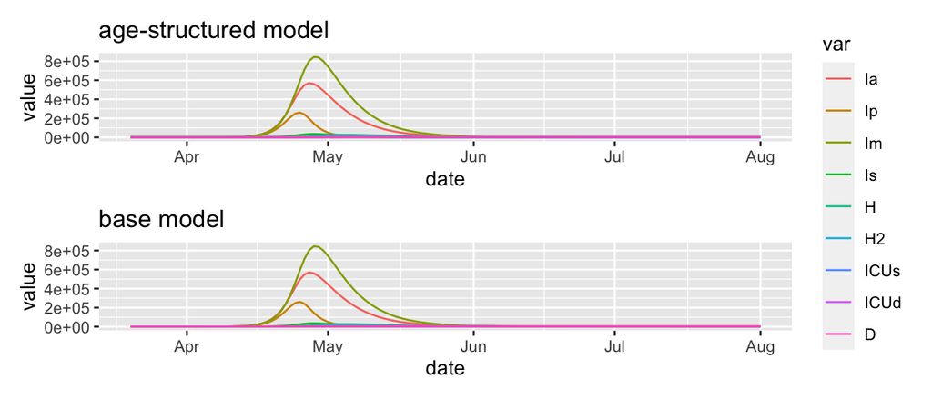

Full age-structured results:

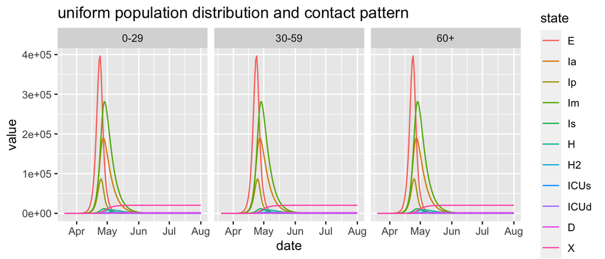

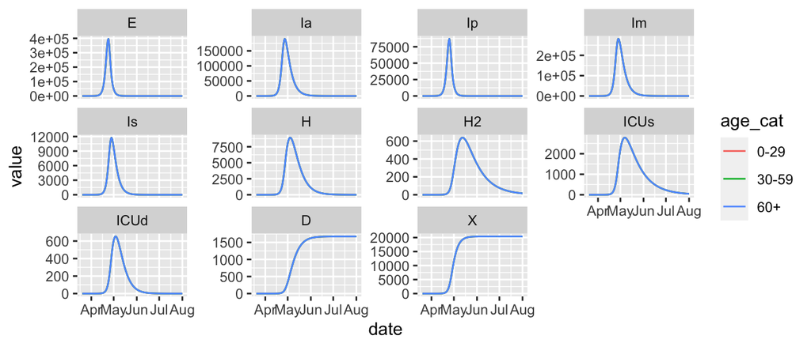

## Diagonal contact matrix

A diagonal contact matrix decouples the age-specific epidemics entirely.

There is a test checking that identical epidemics are generated within each age group with a diagonal contact matrix and a uniform population distribution.

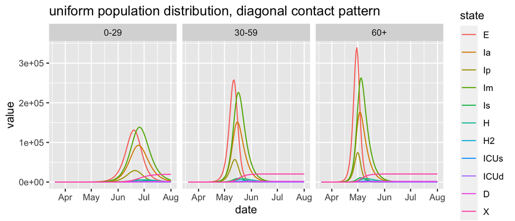

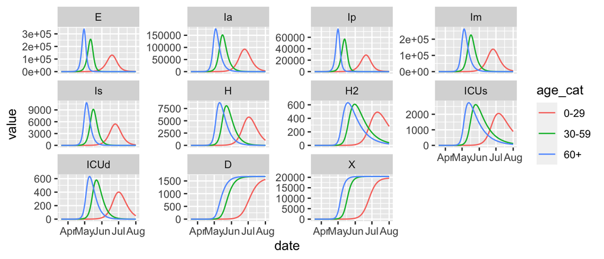

## Using a “compound” contact matrix

A “compound” contact matrix keeps the majority of contacts within an age-group, and contacts outside of an age group are uniformly distributed across all other age groups. It’s essentially the diagonal contact matrix + the uniform contact matrix (row-normalized).

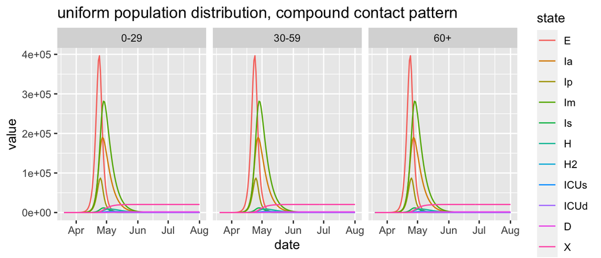

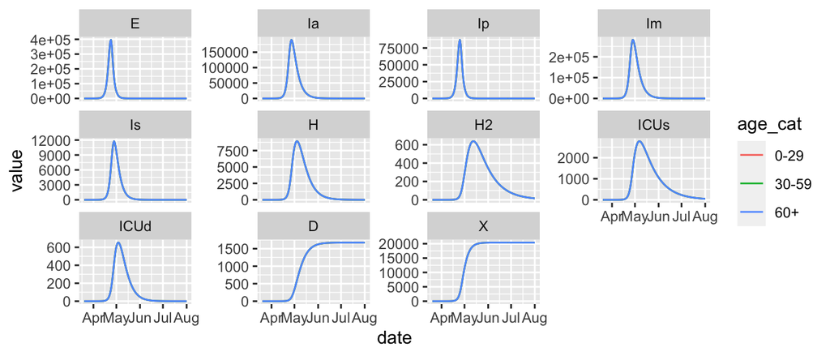

The epidemics look identical, which is unsurprising given $(\beta_0)_i$, $I_i(0)$, and the distribution $p_{ij}$ are identical for all $i$.

```
## [1] "beta0:"
```

```
## [1] 2.0 3.0 1.5
```

```
## [1] "pmat:"
```

```
##            0-29     30-59       60+
## 0-29  0.4000000 0.2000000 0.4000000
## 30-59 0.1333333 0.7666667 0.1000000
## 60+   0.5333333 0.2000000 0.2666667
```

```
## [1] "balance condition implies the following matrix should be symmetric:"
```

```
##        0-29    30-59     60+
## 0-29  4e+06  2000000 4000000
## 30-59 2e+06 11500000 1500000
## 60+   4e+06  1500000 2000000
```

```
## [1] "is symmetric?"
```

```
## [1] TRUE
```

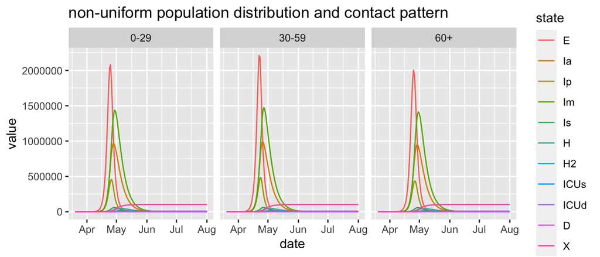

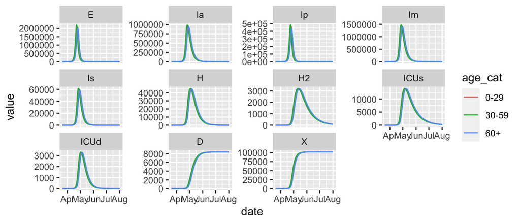

## Non-uniform population distribution, non-uniform contact pattern

```
## [1] "beta0:"
```

```
## [1] 1 2 3
```

```
## [1] "pmat:"
```

```
##            0-29     30-59       60+
## 0-29  0.4000000 0.2000000 0.4000000
## 30-59 0.1333333 0.7666667 0.1000000
## 60+   0.5333333 0.2000000 0.2666667
```

```
## [1] "balance condition implies the following matrix should be symmetric:"
```

```
##        0-29    30-59     60+
## 0-29  4e+06  2000000 4000000
## 30-59 2e+06 11500000 1500000
## 60+   4e+06  1500000 2000000
```

```
## [1] "is symmetric?"
```

```
## [1] TRUE
```

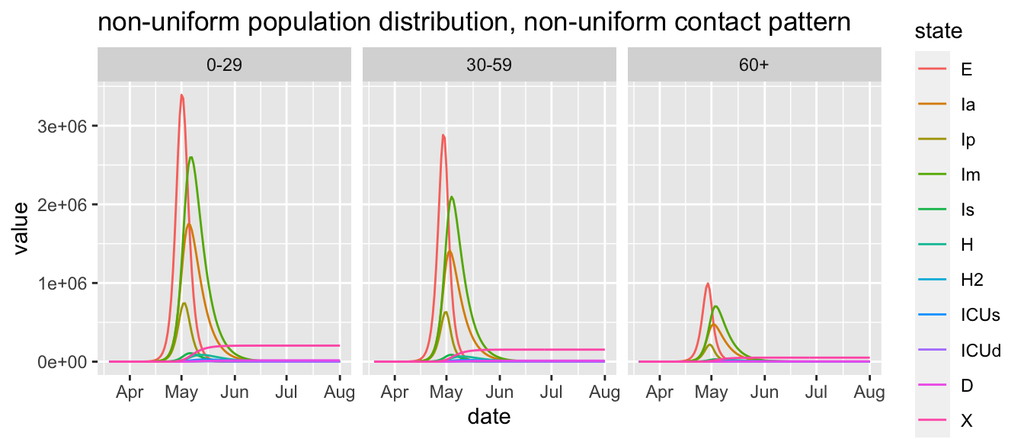

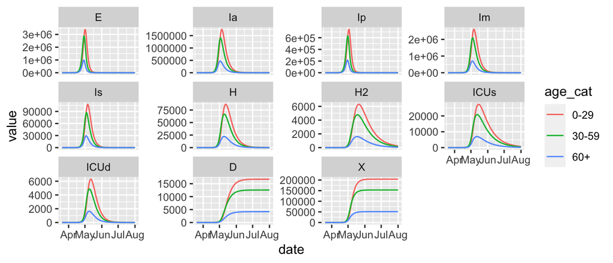

# “Real” contact structure

## Using a Mistry *et al.* contact matrix

Here’s a demo using the Mistry *et al.* contact matrix for Ontario with default (pre-pandemic) contact structure:

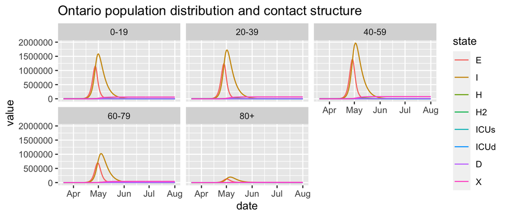

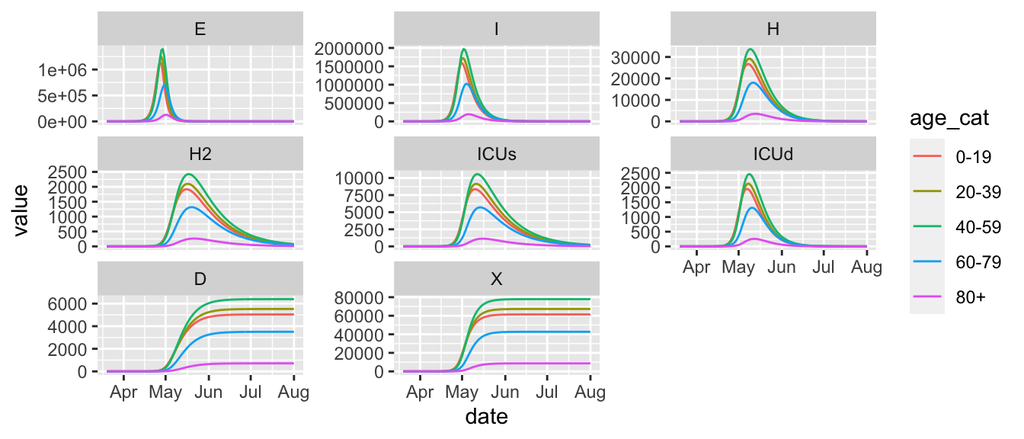

Assuming work contacts are halved, school and community contacts are turned off:

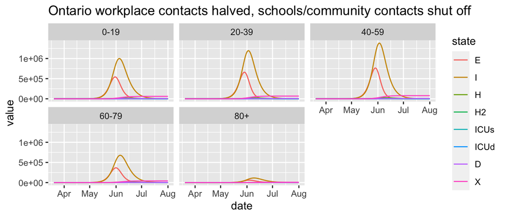

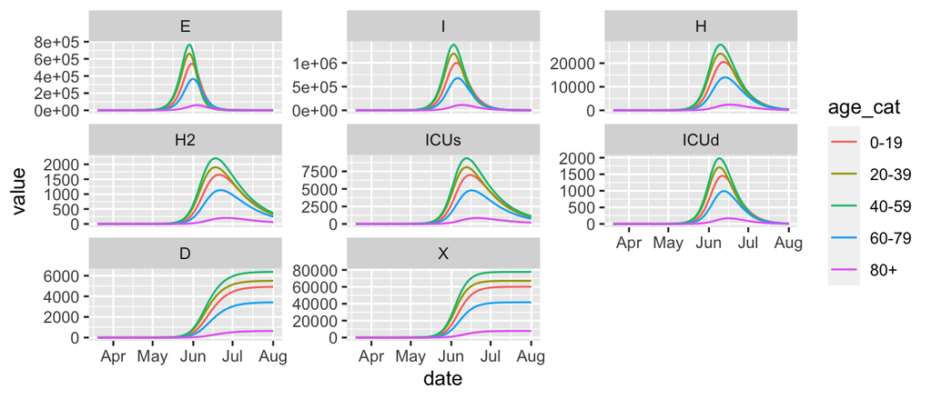

# Time-varying $\beta$

Looking at the code for time-varying params (notes in `IP_explore_codebase`), it should just work for ageified transmission. Let’s try that here:

```
## [1] "comparing base and ageified simulation results... equal?"
```

```
## [1] TRUE
```

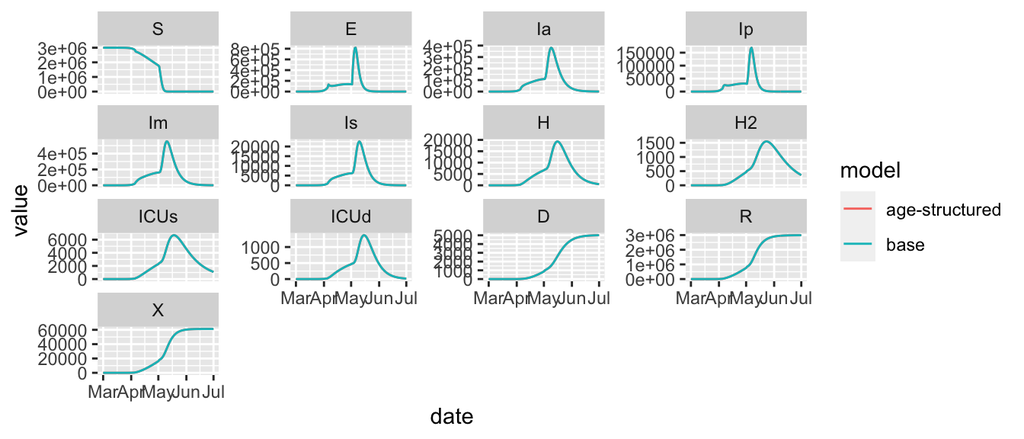

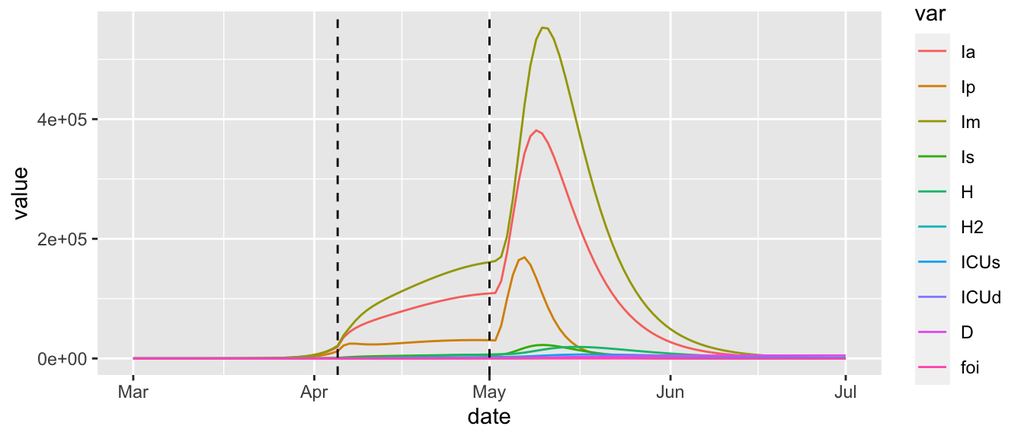